# Do the ‘R’ Thing

Feb 08, 2018

## Motivation for this workshop

## By way of introduction

- I am a doctoral student in Urban Education,
- began using R for data analysis in 2009,
- frustrated with R, began using Pandas and iPython instead,
- in 2016, fell in love with R again.

## Brought to you by the letter ‘R’

[figure not shown]

## Data analysis, the right way and wrong way

[figure not shown]

[figure not shown]

## A schematic view of data analysis process

[figure not shown]

r4ds.had.co.nz

## Why you use R for data analysis

### Or should, if you are not already

- It is **open source and free** unlike Stata, SAS, SPSS, etc.
- Good **documentation** and large online community (e.g., [Stack Overflow](https://stackoverflow.com/questions/tagged/r))
- Many available packages from [Comprehensive R Archive Network](https://cran.r-project.org/) and GitHub

## How not to teach R

Garrett Grolemund of RStudio has [shared](https://rviews.rstudio.com/2017/02/22/how-to-teach-r-common-mistakes/) a few principles we will follow:

1. Do not teach R as if it were a programming language
2. Do not avoid the lecture
3. Do not let your workshop become a consulting clinic for installation bugs

## Basics for data analysis

## Welcome to the tidyverse

```r
library(tidyverse)
```

[figure not shown]

## Tidy your data

## Importing data

Use `readr` and `readxl` packages

```r
readr::read_csv('path/to/file.csv')
readr::read_csv('http://host/file.csv')
readxl::read_excel('path/to/file.xlsx')
```

## Load up sample data

```r
library(nycflights13)
flights %>% head(5)
```

```
## # A tibble: 5 x 19
##    year month   day dep_time sched_dep_time dep_delay arr_time sched_arr_time arr_delay carrier flight tailnum origin dest  air_time distance  hour minute time_hour
##   <int> <int> <int>    <int>          <int>     <dbl>    <int>          <int>     <dbl> <chr>    <int> <chr>   <chr>  <chr>    <dbl>    <dbl> <dbl>  <dbl> <dttm>
## 1  2013     1     1      517            515      2.00      830            819      11.0 UA        1545 N14228  EWR    IAH        227     1400  5.00   15.0 2013-01-01 05:00:00
## 2  2013     1     1      533            529      4.00      850            830      20.0 UA        1714 N24211  LGA    IAH        227     1416  5.00   29.0 2013-01-01 05:00:00
## 3  2013     1     1      542            540      2.00      923            850      33.0 AA        1141 N619AA  JFK    MIA        160     1089  5.00   40.0 2013-01-01 05:00:00
## 4  2013     1     1      544            545     -1.00     1004           1022     -18.0 B6         725 N804JB  JFK    BQN        183     1576  5.00   45.0 2013-01-01 05:00:00
## 5  2013     1     1      554            600     -6.00      812            837     -25.0 DL         461 N668DN  LGA    ATL        116      762  6.00    0   2013-01-01 06:00:00
```

## Pipe it like it’s hot

- **pipes** are expressed with the `%>%` operator
- pipes can be **combined** (chained)
- pipes treat data frames as **immutable**

[figure not shown]

## Selecting and transforming data

```r
flights %>%
  mutate(date = as.Date(sprintf('%d-%.2d-%.2d', year, month, day)),
         weekday = weekdays(date)) %>%
  select(date, weekday, air_time, distance) %>%
  head(5)
```

```
## # A tibble: 5 x 4
##   date       weekday air_time distance
##   <date>     <chr>      <dbl>    <dbl>
## 1 2013-01-01 Tuesday      227     1400
## 2 2013-01-01 Tuesday      227     1416
## 3 2013-01-01 Tuesday      160     1089
## 4 2013-01-01 Tuesday      183     1576
## 5 2013-01-01 Tuesday      116      762
```

## Filtering and ordering data

```r
flights %>%
  filter(day < 8) %>%
  arrange(-air_time,distance) %>%
  select(day, carrier, flight, air_time, distance) %>%
  head(5)
```

```
## # A tibble: 5 x 5
##     day carrier flight air_time distance
##   <int> <chr>    <int>    <dbl>    <dbl>
## 1     6 HA          51      691     4983
## 2     5 HA          51      679     4983
## 3     3 HA          51      671     4983
## 4     6 UA          15      665     4963
## 5     5 UA          15      664     4963
```

## Let’s get statistical

```r
flights %>%
  summarise(maxairtime = max(air_time, na.rm=TRUE))
```

```
## # A tibble: 1 x 1
##   maxairtime
##        <dbl>
## 1        695
```

```r
flights %>%
  summarise(avg_time = mean(air_time, na.rm=TRUE),
            avg_speed = mean(distance/air_time, na.rm=TRUE))
```

```
## # A tibble: 1 x 2
##   avg_time avg_speed
##      <dbl>     <dbl>
## 1      151      6.57
```

## More than one dataset

```r
weather %>%
  filter(origin == 'EWR') %>%
  head(5)
```

```
## # A tibble: 5 x 15
##   origin  year month   day  hour  temp  dewp humid wind_dir wind_speed wind_gust precip pressure visib time_hour
##   <chr>  <dbl> <dbl> <int> <int> <dbl> <dbl> <dbl>    <dbl>      <dbl>     <dbl>  <dbl>    <dbl> <dbl> <dttm>
## 1 EWR     2013  1.00     1     0  37.0  21.9  54.0      230       10.4      11.9      0     1014  10.0 2012-12-31 19:00:00
## 2 EWR     2013  1.00     1     1  37.0  21.9  54.0      230       13.8      15.9      0     1013  10.0 2012-12-31 20:00:00
## 3 EWR     2013  1.00     1     2  37.9  21.9  52.1      230       12.7      14.6      0     1013  10.0 2012-12-31 21:00:00
## 4 EWR     2013  1.00     1     3  37.9  23.0  54.5      230       13.8      15.9      0     1013  10.0 2012-12-31 22:00:00
## 5 EWR     2013  1.00     1     4  37.9  24.1  57.0      240       15.0      17.2      0     1013  10.0 2012-12-31 23:00:00
```

## Get It Together

### Combining weather and flights data

```r
flightsweather <- flights %>%
  left_join(weather, by = c("origin", "year", "month", "day", "hour")) %>%
  select(origin, dep_delay, wind_speed)
flightsweather %>% head(5)
```

```
## # A tibble: 5 x 3
##   origin dep_delay wind_speed
##   <chr>      <dbl>      <dbl>
## 1 EWR         2.00       NA
## 2 LGA         4.00       NA
## 3 JFK         2.00       NA
## 4 JFK        -1.00       NA
## 5 LGA        -6.00       13.8
```

## Tidying data

```r
table4a
```

```
## # A tibble: 3 x 3
##   country     `1999` `2000`
## * <chr>        <int>  <int>
## 1 Afghanistan    745   2666
## 2 Brazil       37737  80488
## 3 China       212258 213766
```

- Example “pivot” table where column names contain years
- We want to “unpivot” these columns names as values for the variable `year`

```r
table4a %>%
  gather(-country, key = "year", value = "cases")
```

```
## # A tibble: 6 x 3
##   country     year   cases
##   <chr>       <chr>  <int>
## 1 Afghanistan 1999     745
## 2 Brazil      1999   37737
## 3 China       1999  212258
## 4 Afghanistan 2000    2666
## 5 Brazil      2000   80488
## 6 China       2000  213766
```

## Explore variables with visualizations

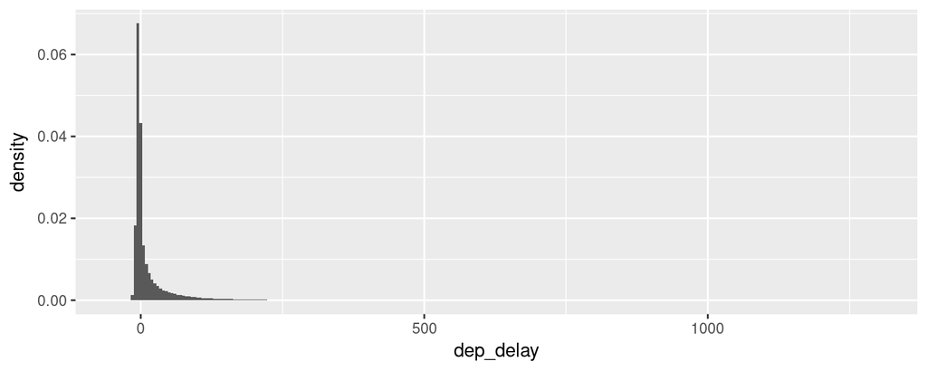

```r
flightsweather %>%
  na.omit() %>%
  ggplot(aes(x=dep_delay)) +
    geom_histogram(aes(y=..density..),
                   binwidth = 5)
```

## More than just pretty graphics

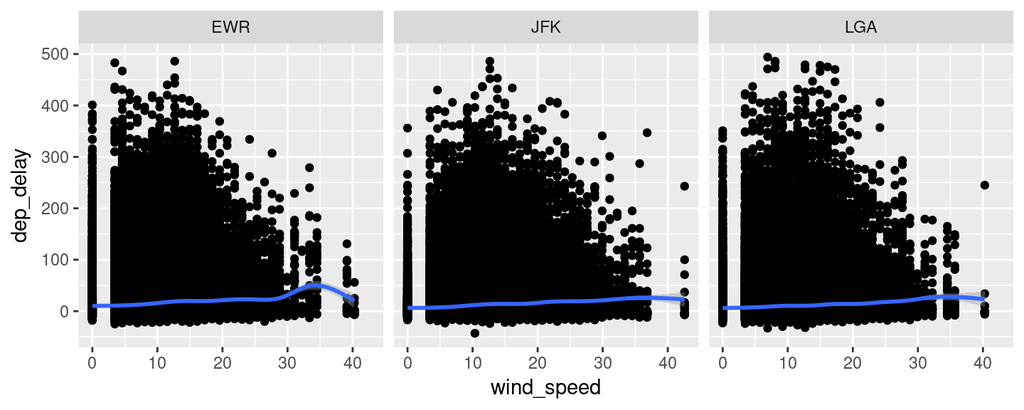

```r
flightsweather %>%
  filter(wind_speed < 250 & dep_delay < 500) %>%
  ggplot(aes(x=wind_speed, y=dep_delay)) +
    geom_point() +
    geom_smooth() +
    facet_grid(. ~ origin)
```

## Let’s hit the gym

## First, stretch

Take a five minute break.

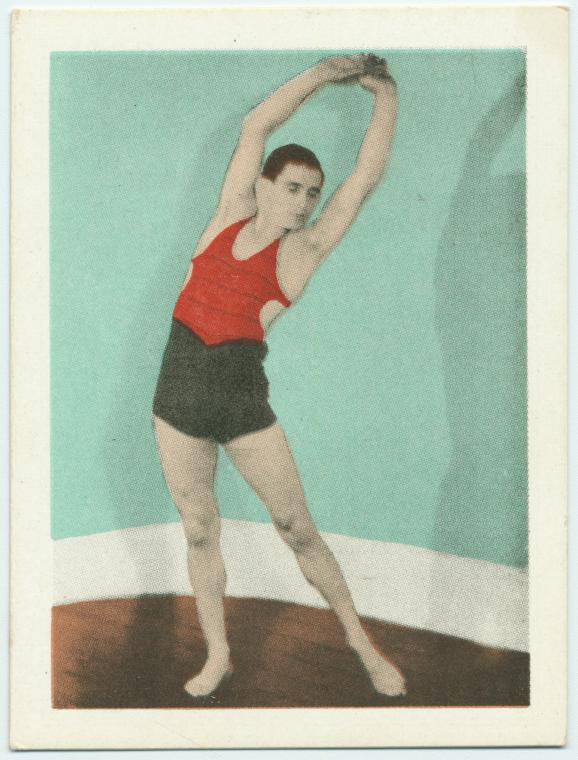

## Proper gym equipment

### R and RStudio Desktop

- Install [R](https://r-project.org/) and [RStudio Desktop](https://www.rstudio.com/products/rstudio/download/)
- Or, create an account on [rstudio.cloud](http://rstudio.cloud/) and copy the [project](https://rstudio.cloud/project/16464) for this workshop
- Read the RStudio Desktop [documentation](https://support.rstudio.com/hc/en-us/sections/200107586-Using-the-RStudio-IDE)

## Start with free weights

### Use the R Console

Familiarize yourself with the Console

```r
version
sessionInfo()
x <- date()
x
```

## Remember gym etiquette

### Create an R project

- Don’t make a mess! Use Projects
- *File > New Directory > New Project*

[figure not shown]

## Tracking your progress

### Keep an R Notebook

- A notebook is an **rmarkdown** document intended for recording your analyses
- Rather than comment your code, your documentation contains code
- Chunks are executed **independently** and **interactively**

## What’s your max, bro?

### Keeping research reproducible

- Notebooks are an example of **literate programming**
- Notebooks are **reproducible** documents
- Rmarkdown generates publication-quality output
- Share project as a git repository: [do-the-right-thing](https://github.com/GCDigitalFellows/do-the-r-thing)

## Data Exercise

Data exercise notebook